# SupervisorLearning_Project

## Thera Bank Personal Loan Campaign

#### Data Description:

The dataset contains data on 5000 customers. The data include customer demographic information (age, income, etc.), the customer's relationship with the bank (mortgage, securities account, etc.), and the customer response to the last personal loan campaign (Personal Loan). Among these 5000 customers, only 480 (= 9.6%) accepted the personal loan that was offered to them in the earlier campaign.

#### Domain:

Banking

#### Context:

This case is about a bank (Thera Bank) whose management wants to explore ways of converting its liability customers to personal loan customers (while retaining them as depositors). A campaign that the bank ran last year for liability customers showed a healthy conversion rate of over 9% success. This has encouraged the retail marketing department to devise campaigns with better target marketing to increase the success ratio with a minimal budget.

#### Attribute Information:

- ID: Customer ID
- Age: Customer's age in completed years
- Experience: #years of professional experience
- Income: Annual income of the customer
- ZIP Code: Home Address ZIP
- Family: Family size of the customer
- CCAvg: Avg. spending on credit cards per month
- Education: Education Level. 1: Undergrad; 2: Graduate; 3: Advanced/Professional
- Mortgage: Value of house mortgage if any
- Personal Loan: Did this customer accept the personal loan offered in the last campaign?
- Securities Account: Does the customer have a securities account with the bank?
- CD Account: Does the customer have a certificate of deposit (CD) account with the bank?
- Online: Does the customer use internet banking facilities?
- Credit card: Does the customer use a credit card issued by the bank?

#### Learning Outcomes:

- Exploratory Data Analysis
- Preparing the data to train a model
- Training and making predictions using a classification model
- Model evaluation

#### Objective:

The classification goal is to predict the likelihood of a liability customer buying personal loans.

#### Steps and tasks:

- Import the datasets and libraries, check datatype, statistical summary, shape, null values or incorrect imputation. (5 marks)
- EDA: Study the data distribution in each attribute and target variable, share your findings (20 marks)
  - Number of unique in each column?
  - Number of people with zero mortgage?
  - Number of people with zero credit card spending per month?
  - Value counts of all categorical columns.
  - Univariate and Bivariate
  - Get data model ready
- Split the data into training and test set in the ratio of 70:30 respectively (5 marks)
- Use the Logistic Regression model to predict whether the customer will take a personal loan or not. Print all the metrics related to evaluating the model performance (accuracy, recall, precision, f1score, and roc_auc_score). Draw a heatmap to display confusion matrix (15 marks)
- Find out coefficients of all the attributes and show the output in a data frame with column names? For test data show all the rows where the predicted class is not equal to the observed class (10 marks)
- Give conclusion related to the Business understanding of your model? (5 marks)

#### Analysis : Srikanth Karimisetty

## 1. Import the datasets and libraries, check datatype, statistical summary, shape, null values or incorrect imputation. (5 marks)

```python
import numpy as np
import pandas as pd
import matplotlib.pyplot as plt
%matplotlib inline
import seaborn as sns
sns.set(color_codes=True)
```

```python
loanData = pd.read_csv("Bank_Personal_Loan_Modelling.csv")
loanData.shape # Check number of columns and rows in data frame
```

```
(5000, 14)
```

```python
# Check Sample Data
loanData.head()
```

|  | ID | Age | Experience | Income | ZIP Code | Family | CCAvg | Education | Mortgage | Personal Loan | Securities Account | CD Account | Online | CreditCard |
| --- | --- | --- | --- | --- | --- | --- | --- | --- | --- | --- | --- | --- | --- | --- |
| 0 | 1 | 25 | 1 | 49 | 91107 | 4 | 1.6 | 1 | 0 | 0 | 1 | 0 | 0 | 0 |
| 1 | 2 | 45 | 19 | 34 | 90089 | 3 | 1.5 | 1 | 0 | 0 | 1 | 0 | 0 | 0 |
| 2 | 3 | 39 | 15 | 11 | 94720 | 1 | 1.0 | 1 | 0 | 0 | 0 | 0 | 0 | 0 |
| 3 | 4 | 35 | 9 | 100 | 94112 | 1 | 2.7 | 2 | 0 | 0 | 0 | 0 | 0 | 0 |
| 4 | 5 | 35 | 8 | 45 | 91330 | 4 | 1.0 | 2 | 0 | 0 | 0 | 0 | 0 | 1 |

```python
# Describe the data to check datatypes
loanData.info()
```

```
<class 'pandas.core.frame.DataFrame'>
RangeIndex: 5000 entries, 0 to 4999
Data columns (total 14 columns):
 #   Column              Non-Null Count  Dtype
---  ------              --------------  -----
 0   ID                  5000 non-null   int64
 1   Age                 5000 non-null   int64
 2   Experience          5000 non-null   int64
 3   Income              5000 non-null   int64
 4   ZIP Code            5000 non-null   int64
 5   Family              5000 non-null   int64
 6   CCAvg               5000 non-null   float64
 7   Education           5000 non-null   int64
 8   Mortgage            5000 non-null   int64
 9   Personal Loan       5000 non-null   int64
 10  Securities Account  5000 non-null   int64
 11  CD Account          5000 non-null   int64
 12  Online              5000 non-null   int64
 13  CreditCard          5000 non-null   int64
dtypes: float64(1), int64(13)
memory usage: 547.0 KB
```

```python
# Describe the data to see Summary
loanData.describe()
```

|  | ID | Age | Experience | Income | ZIP Code | Family | CCAvg | Education | Mortgage | Personal Loan | Securities Account | CD Account | Online | CreditCard |
| --- | --- | --- | --- | --- | --- | --- | --- | --- | --- | --- | --- | --- | --- | --- |
| count | 5000.000000 | 5000.000000 | 5000.000000 | 5000.000000 | 5000.000000 | 5000.000000 | 5000.000000 | 5000.000000 | 5000.000000 | 5000.000000 | 5000.000000 | 5000.00000 | 5000.000000 | 5000.000000 |
| mean | 2500.500000 | 45.338400 | 20.104600 | 73.774200 | 93152.503000 | 2.396400 | 1.937938 | 1.881000 | 56.498800 | 0.096000 | 0.104400 | 0.06040 | 0.596800 | 0.294000 |
| std | 1443.520003 | 11.463166 | 11.467954 | 46.033729 | 2121.852197 | 1.147663 | 1.747659 | 0.839869 | 101.713802 | 0.294621 | 0.305809 | 0.23825 | 0.490589 | 0.455637 |
| min | 1.000000 | 23.000000 | -3.000000 | 8.000000 | 9307.000000 | 1.000000 | 0.000000 | 1.000000 | 0.000000 | 0.000000 | 0.000000 | 0.00000 | 0.000000 | 0.000000 |
| 25% | 1250.750000 | 35.000000 | 10.000000 | 39.000000 | 91911.000000 | 1.000000 | 0.700000 | 1.000000 | 0.000000 | 0.000000 | 0.000000 | 0.00000 | 0.000000 | 0.000000 |
| 50% | 2500.500000 | 45.000000 | 20.000000 | 64.000000 | 93437.000000 | 2.000000 | 1.500000 | 2.000000 | 0.000000 | 0.000000 | 0.000000 | 0.00000 | 1.000000 | 0.000000 |
| 75% | 3750.250000 | 55.000000 | 30.000000 | 98.000000 | 94608.000000 | 3.000000 | 2.500000 | 3.000000 | 101.000000 | 0.000000 | 0.000000 | 0.00000 | 1.000000 | 1.000000 |
| max | 5000.000000 | 67.000000 | 43.000000 | 224.000000 | 96651.000000 | 4.000000 | 10.000000 | 3.000000 | 635.000000 | 1.000000 | 1.000000 | 1.00000 | 1.000000 | 1.000000 |

Some Analysis on the above Statistical data -------------------------------------------- There is some anamoly with the experience field. I see -ve experiece for some rows.

```python
# check there are any null values in data set
loanData.isnull().values.any()
```

```
False
```

## 2.EDA: Study the data distribution in each attribute and target variable, share your findings (20 marks)

```python
# Number of Unique in Each Column
uniqueValues = loanData.nunique()
print("Count Unique values in each column")
print(uniqueValues)
```

```
Count Unique values in each column
ID                    5000
Age                     45
Experience              47
Income                 162
ZIP Code               467
Family                   4
CCAvg                  108
Education                3
Mortgage               347
Personal Loan            2
Securities Account       2
CD Account               2
Online                   2
CreditCard               2
dtype: int64
```

```python
#Number of people with zero mortgage?
print("Number of people with zero mortgage : " + str(sum(loanData["Mortgage"]==0)) )
#Number of people with zero credit card spending per month?
print("Number of people with zero credit card spending per month : " +str(sum(loanData["CreditCard"]==0)))
#Number of people with Personal Loan
print("Number of people with Personal Loan : " + str(sum(loanData["Personal Loan"]==1)))
```

```
Number of people with zero mortgage : 3462
Number of people with zero credit card spending per month : 3530
Number of people with Personal Loan : 480
```

### Univarient Analysis

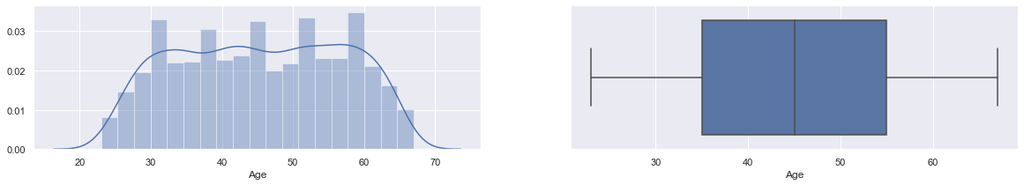

```python
# Data analysis for Non Categorical
plt.figure(figsize=(20,3))
plt.subplot(1, 2, 1)
sns.distplot(loanData["Age"])
plt.subplot(1, 2, 2)
sns.boxplot(loanData["Age"])
plt.show()
```

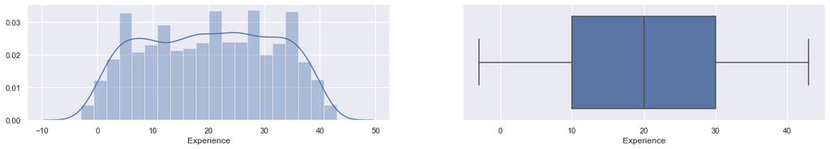

```python
# Data analysis for Non Categorical
plt.figure(figsize=(20,3))
plt.subplot(1, 2, 1)
sns.distplot(loanData["Experience"])
plt.subplot(1, 2, 2)
sns.boxplot(loanData["Experience"])
plt.show()
```

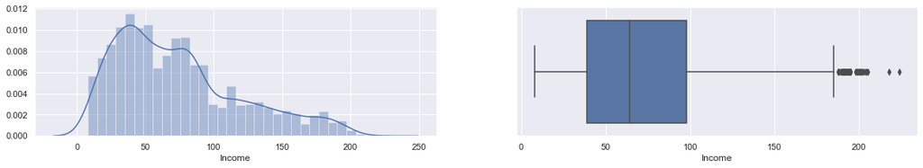

```python
# Data analysis for Non Categorical
plt.figure(figsize=(20,3))
plt.subplot(1, 2, 1)
sns.distplot(loanData["Income"])
plt.subplot(1, 2, 2)
sns.boxplot(loanData["Income"])
plt.show()
```

From Above Box Plot ,we can see there are some outliers for Income

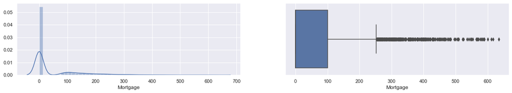

```python
# Data analysis for Non Categorical
plt.figure(figsize=(20,3))
plt.subplot(1, 2, 1)
sns.distplot(loanData["Mortgage"])
plt.subplot(1, 2, 2)
sns.boxplot(loanData["Mortgage"])
plt.show()
```

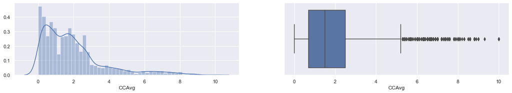

```python
# Data analysis for Non Categorical
plt.figure(figsize=(20,3))
plt.subplot(1, 2, 1)
sns.distplot(loanData["CCAvg"])
plt.subplot(1, 2, 2)
sns.boxplot(loanData["CCAvg"])
plt.show()
```

From Above Box Plot ,we can see there are some outliers for CCAvg . Should we drop ??

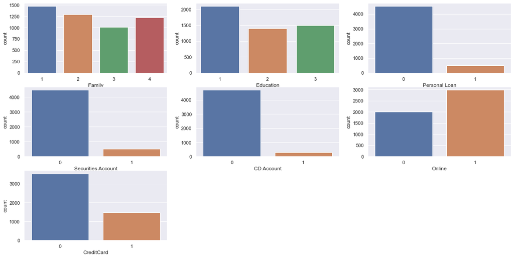

```python
plt.figure(figsize=(20,10))
plt.subplot(3, 3, 1)
sns.countplot(loanData["Family"])
plt.subplot(3, 3, 2)
sns.countplot(loanData["Education"])
plt.subplot(3, 3, 3)
sns.countplot(loanData["Personal Loan"])
plt.subplot(3, 3, 4)
sns.countplot(loanData["Securities Account"])
plt.subplot(3, 3, 5)
sns.countplot(loanData["CD Account"])
plt.subplot(3, 3, 6)
sns.countplot(loanData["Online"])
plt.subplot(3, 3, 7)
sns.countplot(loanData["CreditCard"])
plt.show()
```

### Bivariant analysis

```python
# Let us look at the target column which is 'Loan_Status' to understand how the data is distributed amongst the various values
loanData.groupby(["Personal Loan"]).mean()
```

| Personal Loan | ID | Age | Experience | Income | ZIP Code | Family | CCAvg | Education | Mortgage | Securities Account | CD Account | Online | CreditCard |
| --- | --- | --- | --- | --- | --- | --- | --- | --- | --- | --- | --- | --- | --- |
| 0 | 2512.165487 | 45.367257 | 20.132301 | 66.237389 | 93152.428761 | 2.373451 | 1.729009 | 1.843584 | 51.789381 | 0.102212 | 0.035841 | 0.595796 | 0.293584 |
| 1 | 2390.650000 | 45.066667 | 19.843750 | 144.745833 | 93153.202083 | 2.612500 | 3.905354 | 2.233333 | 100.845833 | 0.125000 | 0.291667 | 0.606250 | 0.297917 |

People with High income tend to take more personal loans.

People with High CCAvg tend to take more personal loans.

```python
pd.crosstab(loanData['Family'],loanData['Personal Loan'],normalize='index')
```

| Personal Loan Family | 0 | 1 |
| --- | --- | --- |
| 1 | 0.927310 | 0.072690 |
| 2 | 0.918210 | 0.081790 |
| 3 | 0.868317 | 0.131683 |
| 4 | 0.890344 | 0.109656 |

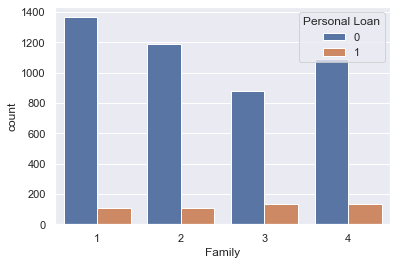

```python
sns.countplot(x="Family",data=loanData,hue='Personal Loan')
plt.show()
```

```python
pd.crosstab(loanData['Education'],loanData['Personal Loan'],normalize='index')
```

| Personal Loan Education | 0 | 1 |
| --- | --- | --- |
| 1 | 0.955630 | 0.044370 |
| 2 | 0.870278 | 0.129722 |
| 3 | 0.863424 | 0.136576 |

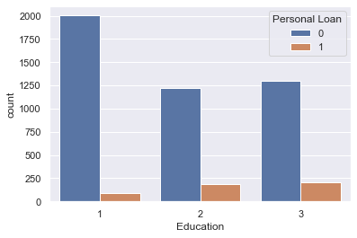

```python
sns.countplot(x="Education",data=loanData,hue='Personal Loan')
plt.show()
```

Personal loan increase as education level increase

```python
pd.crosstab(loanData['Securities Account'],loanData['Personal Loan'],normalize='index')
```

| Personal Loan Securities Account | 0 | 1 |
| --- | --- | --- |
| 0 | 0.906208 | 0.093792 |
| 1 | 0.885057 | 0.114943 |

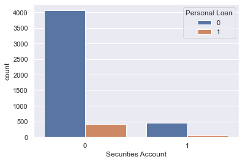

```python
sns.countplot(x="Securities Account",data=loanData,hue='Personal Loan')
plt.show()
```

Security Accounts are more that Personal Loan

```python
pd.crosstab(loanData['CD Account'],loanData['Personal Loan'],normalize='index')
```

| Personal Loan CD Account | 0 | 1 |
| --- | --- | --- |
| 0 | 0.927629 | 0.072371 |
| 1 | 0.536424 | 0.463576 |

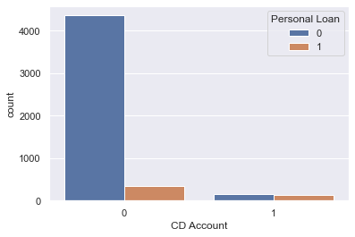

```python
sns.countplot(x="CD Account",data=loanData,hue='Personal Loan')
plt.show()
```

```python
pd.crosstab(loanData['Online'],loanData['Personal Loan'],normalize='index')
```

| Personal Loan Online | 0 | 1 |
| --- | --- | --- |
| 0 | 0.90625 | 0.09375 |
| 1 | 0.90248 | 0.09752 |

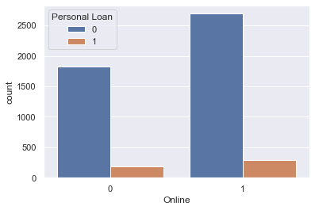

```python
sns.countplot(x="Online",data=loanData,hue='Personal Loan')
plt.show()
```

```python
pd.crosstab(loanData['CreditCard'],loanData['Personal Loan'],normalize='index')
```

| Personal Loan CreditCard | 0 | 1 |
| --- | --- | --- |
| 0 | 0.904533 | 0.095467 |
| 1 | 0.902721 | 0.097279 |

```python
#Identify Correlation is data
loanData.corr()
```

|  | ID | Age | Experience | Income | ZIP Code | Family | CCAvg | Education | Mortgage | Personal Loan | Securities Account | CD Account | Online | CreditCard |
| --- | --- | --- | --- | --- | --- | --- | --- | --- | --- | --- | --- | --- | --- | --- |
| ID | 1.000000 | -0.008473 | -0.008326 | -0.017695 | 0.013432 | -0.016797 | -0.024675 | 0.021463 | -0.013920 | -0.024801 | -0.016972 | -0.006909 | -0.002528 | 0.017028 |
| Age | -0.008473 | 1.000000 | 0.994215 | -0.055269 | -0.029216 | -0.046418 | -0.052012 | 0.041334 | -0.012539 | -0.007726 | -0.000436 | 0.008043 | 0.013702 | 0.007681 |
| Experience | -0.008326 | 0.994215 | 1.000000 | -0.046574 | -0.028626 | -0.052563 | -0.050077 | 0.013152 | -0.010582 | -0.007413 | -0.001232 | 0.010353 | 0.013898 | 0.008967 |
| Income | -0.017695 | -0.055269 | -0.046574 | 1.000000 | -0.016410 | -0.157501 | 0.645984 | -0.187524 | 0.206806 | 0.502462 | -0.002616 | 0.169738 | 0.014206 | -0.002385 |
| ZIP Code | 0.013432 | -0.029216 | -0.028626 | -0.016410 | 1.000000 | 0.011778 | -0.004061 | -0.017377 | 0.007383 | 0.000107 | 0.004704 | 0.019972 | 0.016990 | 0.007691 |
| Family | -0.016797 | -0.046418 | -0.052563 | -0.157501 | 0.011778 | 1.000000 | -0.109275 | 0.064929 | -0.020445 | 0.061367 | 0.019994 | 0.014110 | 0.010354 | 0.011588 |
| CCAvg | -0.024675 | -0.052012 | -0.050077 | 0.645984 | -0.004061 | -0.109275 | 1.000000 | -0.136124 | 0.109905 | 0.366889 | 0.015086 | 0.136534 | -0.003611 | -0.006689 |
| Education | 0.021463 | 0.041334 | 0.013152 | -0.187524 | -0.017377 | 0.064929 | -0.136124 | 1.000000 | -0.033327 | 0.136722 | -0.010812 | 0.013934 | -0.015004 | -0.011014 |
| Mortgage | -0.013920 | -0.012539 | -0.010582 | 0.206806 | 0.007383 | -0.020445 | 0.109905 | -0.033327 | 1.000000 | 0.142095 | -0.005411 | 0.089311 | -0.005995 | -0.007231 |
| Personal Loan | -0.024801 | -0.007726 | -0.007413 | 0.502462 | 0.000107 | 0.061367 | 0.366889 | 0.136722 | 0.142095 | 1.000000 | 0.021954 | 0.316355 | 0.006278 | 0.002802 |
| Securities Account | -0.016972 | -0.000436 | -0.001232 | -0.002616 | 0.004704 | 0.019994 | 0.015086 | -0.010812 | -0.005411 | 0.021954 | 1.000000 | 0.317034 | 0.012627 | -0.015028 |
| CD Account | -0.006909 | 0.008043 | 0.010353 | 0.169738 | 0.019972 | 0.014110 | 0.136534 | 0.013934 | 0.089311 | 0.316355 | 0.317034 | 1.000000 | 0.175880 | 0.278644 |
| Online | -0.002528 | 0.013702 | 0.013898 | 0.014206 | 0.016990 | 0.010354 | -0.003611 | -0.015004 | -0.005995 | 0.006278 | 0.012627 | 0.175880 | 1.000000 | 0.004210 |
| CreditCard | 0.017028 | 0.007681 | 0.008967 | -0.002385 | 0.007691 | 0.011588 | -0.006689 | -0.011014 | -0.007231 | 0.002802 | -0.015028 | 0.278644 | 0.004210 | 1.000000 |

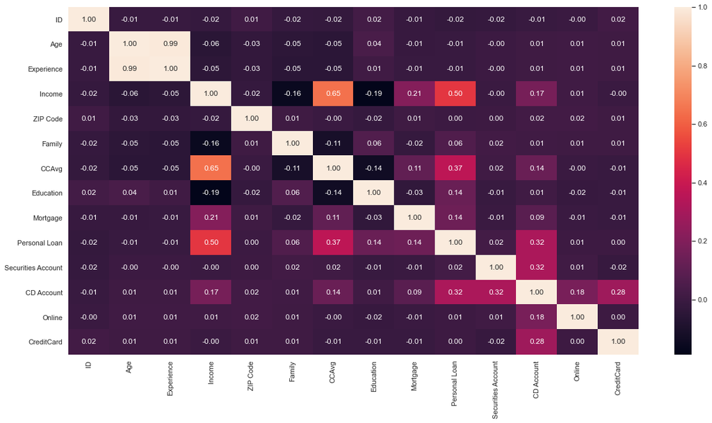

```python
# Lets Plot correlation using heatmap

plt.figure(figsize=(20,10))
sns.heatmap(loanData.corr(), annot=True, fmt=".2f")
plt.show()
```

Above Heat Map indicates that Experience and Age are highly correlated (0.99). There are bunch of negative correlations

### Get Data Model Ready

```python
# check any negative values for Experience column
sum(loanData["Experience"]<0)
```

```
52
```

```python
# Replace the -ve experience values 0
loanData.loc[loanData["Experience"] < 0, "Experience"] = 0
# check any negative values for Experience column
sum(loanData["Experience"]<0)
```

```
0
```

```python
# Based on the Unique Elements analysis done above
# Family, Education, Personal Loan, Securities Account, CD Account, Online and CreditCard variables are categorical variables.
# Lets convert them to Categorical Varaibles
loanData['Family'] = loanData['Family'].astype('category')
loanData['Education'] = loanData['Education'].astype('category')
loanData['Personal Loan'] = loanData['Personal Loan'].astype('category')
loanData['Securities Account'] = loanData['Securities Account'].astype('category')
loanData['CD Account'] = loanData['CD Account'].astype('category')
loanData['Online'] = loanData['Online'].astype('category')
loanData['CreditCard'] = loanData['CreditCard'].astype('category')
loanData.info()
```

```
<class 'pandas.core.frame.DataFrame'>
RangeIndex: 5000 entries, 0 to 4999
Data columns (total 14 columns):
 #   Column              Non-Null Count  Dtype
---  ------              --------------  -----
 0   ID                  5000 non-null   int64
 1   Age                 5000 non-null   int64
 2   Experience          5000 non-null   int64
 3   Income              5000 non-null   int64
 4   ZIP Code            5000 non-null   int64
 5   Family              5000 non-null   category
 6   CCAvg               5000 non-null   float64
 7   Education           5000 non-null   category
 8   Mortgage            5000 non-null   int64
 9   Personal Loan       5000 non-null   category
 10  Securities Account  5000 non-null   category
 11  CD Account          5000 non-null   category
 12  Online              5000 non-null   category
 13  CreditCard          5000 non-null   category
dtypes: category(7), float64(1), int64(6)
memory usage: 308.5 KB
```

```python
# We don't need ID column, ZIP code so let drop it. Also Drop "Age" ,Experience and Age are highly correlated (0.99)
loanData = loanData.drop(['ID', 'Age','ZIP Code','Mortgage'], axis =1 )
loanData.head()
```

|  | Experience | Income | Family | CCAvg | Education | Personal Loan | Securities Account | CD Account | Online | CreditCard |
| --- | --- | --- | --- | --- | --- | --- | --- | --- | --- | --- |
| 0 | 1 | 49 | 4 | 1.6 | 1 | 0 | 1 | 0 | 0 | 0 |
| 1 | 19 | 34 | 3 | 1.5 | 1 | 0 | 1 | 0 | 0 | 0 |
| 2 | 15 | 11 | 1 | 1.0 | 1 | 0 | 0 | 0 | 0 | 0 |
| 3 | 9 | 100 | 1 | 2.7 | 2 | 0 | 0 | 0 | 0 | 0 |
| 4 | 8 | 45 | 4 | 1.0 | 2 | 0 | 0 | 0 | 0 | 1 |

## 3 Split the data into training and test set in the ratio of 70:30 respectively (5 marks)

```python
X = loanData.drop('Personal Loan',axis=1)
Y = loanData['Personal Loan']

##Split into training and test set
from sklearn.model_selection import train_test_split
X_train, X_test, y_train, y_test = train_test_split(X, Y, test_size=0.30,random_state=1)
X_train.head()
```

|  | Experience | Income | Family | CCAvg | Education | Securities Account | CD Account | Online | CreditCard |
| --- | --- | --- | --- | --- | --- | --- | --- | --- | --- |
| 1334 | 22 | 35 | 2 | 1.3 | 1 | 0 | 0 | 1 | 0 |
| 4768 | 14 | 39 | 1 | 2.0 | 2 | 0 | 0 | 1 | 0 |
| 65 | 35 | 131 | 1 | 3.8 | 1 | 0 | 0 | 1 | 1 |
| 177 | 3 | 65 | 4 | 1.8 | 2 | 0 | 0 | 0 | 0 |
| 4489 | 13 | 21 | 3 | 0.2 | 2 | 0 | 0 | 1 | 0 |

```python
#Let's Check data Split percentage
print("{0:0.2f}% data is in training set".format((len(X_train)/len(loanData.index)) * 100))
print("{0:0.2f}% data is in test set".format((len(X_test)/len(loanData.index)) * 100))
```

```
70.00% data is in training set
30.00% data is in test set
```

## 4. Use the Logistic Regression model to predict whether the customer will take a personal loan or not. Print all the metrics related to evaluating the model performance (accuracy, recall, precision, f1score, and roc_auc_score). Draw a heatmap to display confusion matrix (15 marks)

```python
from sklearn.metrics import confusion_matrix, recall_score, precision_score, f1_score, roc_auc_score,accuracy_score
from sklearn.linear_model import LogisticRegression

logreg = LogisticRegression(random_state=1,max_iter=10000)
logreg.fit(X_train, y_train)
```

```
LogisticRegression(max_iter=10000, random_state=1)
```

```python
y_predict = logreg.predict(X_test)              # Predicting the target variable on test data
```

```python
# Observe the predicted and observed classes in a dataframe.

compareSet = X_test.copy()
compareSet['Observed Loan Status'] = y_test
compareSet['Predicted Loan Status'] = y_predict
compareSet.head()
```

|  | Experience | Income | Family | CCAvg | Education | Securities Account | CD Account | Online | CreditCard | Observed Loan Status | Predicted Loan Status |
| --- | --- | --- | --- | --- | --- | --- | --- | --- | --- | --- | --- |
| 2764 | 5 | 84 | 1 | 2.9 | 3 | 0 | 0 | 0 | 1 | 0 | 0 |
| 4767 | 9 | 45 | 3 | 0.9 | 1 | 1 | 0 | 0 | 0 | 0 | 0 |
| 3814 | 9 | 35 | 3 | 1.3 | 1 | 0 | 0 | 0 | 0 | 0 | 0 |
| 3499 | 23 | 114 | 1 | 0.3 | 1 | 0 | 0 | 1 | 0 | 0 | 0 |
| 2735 | 12 | 70 | 3 | 2.6 | 2 | 0 | 0 | 1 | 0 | 0 | 0 |

```python
## function to get confusion matrix in a proper format
def draw_cm( actual, predicted ):
    cm = confusion_matrix( actual, predicted)
    sns.heatmap(cm, annot=True,  fmt='.2f', xticklabels = [0,1] , yticklabels = [0,1] )
    plt.ylabel('Observed')
    plt.xlabel('Predicted')
    plt.show()
```

```
Trainig Accuracy :  0.9525714285714286

Testing Accuracy :  0.948

          Recall :  0.5771812080536913

       Precision :  0.8514851485148515

        F1 Score :  0.688

   Roc Auc Score :  0.7830391606515681

Confusion Matrix
```

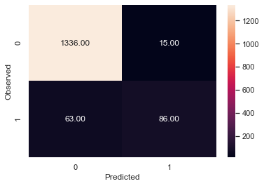

```
None
```

```python
print("Trainig Accuracy : ",logreg.score(X_train,y_train))
print()
print("Testing Accuracy : ",logreg.score(X_test, y_test))
print()
print("          Recall : ",recall_score(y_test,y_predict))
print()
print("       Precision : ",precision_score(y_test,y_predict))
print()
print("        F1 Score : ",f1_score(y_test,y_predict))
print()
print("   Roc Auc Score : ",roc_auc_score(y_test,y_predict))
print()
print('Confusion Matrix')
print(draw_cm(y_test,y_predict))
print()
```

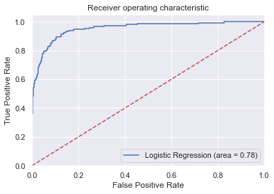

```python
#AUC ROC curve
from sklearn.metrics import roc_auc_score
from sklearn.metrics import roc_curve

logit_roc_auc = roc_auc_score(y_test, logreg.predict(X_test))
fpr, tpr, thresholds = roc_curve(y_test, logreg.predict_proba(X_test)[:,1])
plt.figure()
plt.plot(fpr, tpr, label='Logistic Regression (area = %0.2f)' % logit_roc_auc)
plt.plot([0, 1], [0, 1],'r--')
plt.xlim([0.0, 1.0])
plt.ylim([0.0, 1.05])
plt.xlabel('False Positive Rate')
plt.ylabel('True Positive Rate')
plt.title('Receiver operating characteristic')
plt.legend(loc="lower right")
plt.savefig('Log_ROC')
plt.show()
```

## 5.Find out coefficients of all the attributes and show the output in a data frame with column names? For test data show all the rows where the predicted class is not equal to the observed class (10 marks)

```python
## Feature Importance or Coefficients
fi = pd.DataFrame()
fi['Col'] = X_train.columns
fi['Coeff'] = np.round(abs(logreg.coef_[0]),2)
fi.sort_values(by='Coeff',ascending=False)
```

|  | Col | Coeff |
| --- | --- | --- |
| 6 | CD Account | 3.27 |
| 4 | Education | 1.66 |
| 8 | CreditCard | 0.95 |
| 5 | Securities Account | 0.84 |
| 2 | Family | 0.72 |
| 7 | Online | 0.53 |
| 3 | CCAvg | 0.16 |
| 1 | Income | 0.05 |
| 0 | Experience | 0.01 |

```python
# Test Data where the predicted class is not equal to the observed class
errorPredictedData = compareSet[compareSet["Observed Loan Status"] != compareSet["Predicted Loan Status"]]
print(errorPredictedData.shape)
print("  ")
errorPredictedData.head(100)
```

```
(78, 11)
```

|  | Experience | Income | Family | CCAvg | Education | Securities Account | CD Account | Online | CreditCard | Observed Loan Status | Predicted Loan Status |
| --- | --- | --- | --- | --- | --- | --- | --- | --- | --- | --- | --- |
| 3347 | 41 | 78 | 3 | 2.0 | 3 | 0 | 1 | 1 | 1 | 0 | 1 |
| 4377 | 8 | 145 | 1 | 2.7 | 3 | 0 | 0 | 1 | 0 | 1 | 0 |
| 3988 | 35 | 85 | 1 | 3.4 | 3 | 0 | 1 | 0 | 1 | 1 | 0 |
| 3271 | 27 | 93 | 4 | 4.1 | 2 | 0 | 0 | 0 | 1 | 1 | 0 |
| 349 | 2 | 60 | 2 | 3.0 | 1 | 0 | 0 | 0 | 0 | 1 | 0 |
| ... | ... | ... | ... | ... | ... | ... | ... | ... | ... | ... | ... |
| 1793 | 9 | 113 | 3 | 0.8 | 3 | 0 | 0 | 1 | 0 | 1 | 0 |
| 813 | 25 | 130 | 1 | 1.1 | 2 | 0 | 0 | 1 | 0 | 1 | 0 |
| 3766 | 35 | 108 | 4 | 3.8 | 2 | 0 | 0 | 1 | 0 | 1 | 0 |
| 421 | 3 | 115 | 4 | 3.1 | 2 | 0 | 0 | 0 | 0 | 1 | 0 |
| 3651 | 23 | 140 | 1 | 1.9 | 3 | 0 | 0 | 0 | 1 | 1 | 0 |

78 rows × 11 columns